# Análises de cluster de despesas de pessoal nos Estados

# Evolução temporal dos clusters

O gráfico abaixo mostra dois clusters que são formados na anáse das séries temporais do indicador formado pelo **total de despesas de pessoal/Total de Receitas**. Os pontos mostram para cada trimestre entre 2010 e 2017 como esse indicador se apresentou esse indicador se distribui para cada estado da federação, com exceção do Amapá. As cores mostram os dois grupos formados. As linha vermelha mostra a média do indicador mês a mês para os estados do cluster 1, enquanto que a linha azul mostra essa mesma medida para os estados do cluster 2. Oberva-se com facilidade que os estados do cluster 1 no geral apresentam o indicador com valor superior aos estado cluster 2. Isso pode ser visto tanto pelos pontos como pela linha da média.

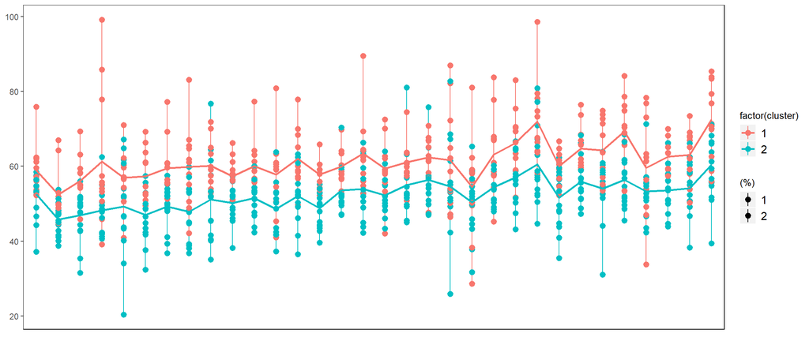

```r
df_min_max_med <-gathered_quociente %>%
  group_by(cluster, Data) %>%
  summarise(min_val = min(quociente),
            max_val = max(quociente),
            med_val = mean(quociente))

gathered_quociente <- gathered_quociente %>%
  inner_join(df_min_max_med)


ggplot(gathered_quociente, aes(x= Data, y = quociente, color = factor(cluster))) +
  geom_pointrange(aes(ymin = min_val, ymax=max_val, fill = factor(cluster),group= fct_reorder(UF, as.numeric(cluster)+media_estado/100, desc= TRUE))) +
  geom_line(aes(y= med_val,group= fct_reorder(UF, as.numeric(cluster)+media_estado/100, desc= TRUE)), size = 1)+
  ylab("UFs ") +
  xlab("Data") +
  theme(legend.title = element_text(size = 10),
        legend.text = element_text(size = 12),
        plot.title = element_text(size=16),
        axis.title=element_text(size=14,face="bold"),
        axis.text.x = element_blank(),
        axis.title.x = element_blank(),
        axis.ticks.x = element_blank(),
        axis.title.y = element_blank(),
        panel.grid = element_blank(),
        panel.background = element_blank(),
        panel.border = element_rect(fill = NA)

        ) +
  labs(fill = "(%)")
```

# Gráfico de densidade dos clusters

O achado do gráfico anterior é reforçado pelo gráfico abaixo que mostra que os indicadores do cluster 1 se distribuem em torno de uma média de 61,1% enquanto que os indicadores do cluster 2 se distribuem em torno de uma média de 52,4%.

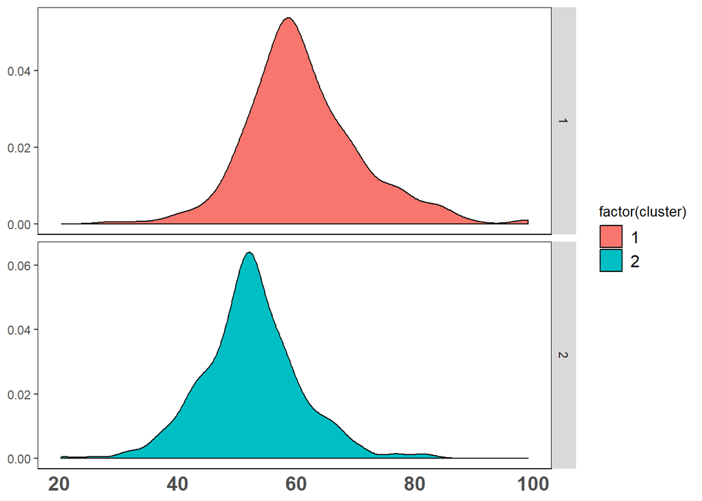

```r
ggplot(gathered_quociente)+
  geom_density(aes(quociente, fill= factor(cluster)))+
  facet_grid(cluster~., scale = "free_y")+
 theme(legend.title = element_text(size = 10),
        legend.text = element_text(size = 12),
        plot.title = element_text(size=16),
        axis.title=element_text(size=14,face="bold"),
        axis.text.x = element_text(size=14,face="bold"),
        axis.title.x = element_blank(),
        axis.ticks.x = element_blank(),
        axis.title.y = element_blank(),
        panel.grid = element_blank(),
        panel.background = element_blank(),
        panel.border = element_rect(fill = NA)

        )
```

# Mapa de calor de clusters formados

Já o próximo gráfico mostra quais são os estados que compõem cada cluster e como o indicador evolui ao longo do tempo. O mapa de calor mostra que no cluster 1 há desde o início predominância de pontos de tonalidade vermelha que vai ficando cada vez mais forte com o passar dos trimestres, enquando que o cluster 2 há no início predominância de pontos de tonalidades azuis que vai aos poucos se tornando vermelho, mas que não chega a atingir os tons mais fortes presentes na representação dos últimos trimestres do cluster 1.

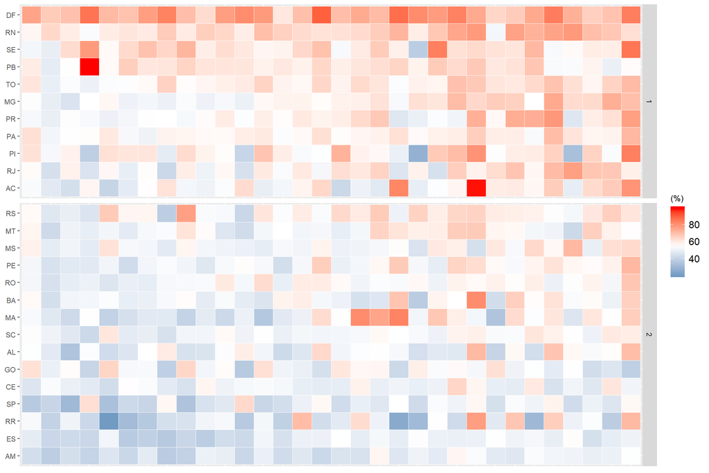

```r
ggplot(gathered_quociente, aes(Data,fct_reorder(UF, as.numeric(cluster)+media_estado/100, desc= TRUE))) +
  geom_tile(aes(fill = quociente), color = "white") +
  scale_fill_gradient2(low = "steelblue", high = "red", midpoint = nivel_critico) +
  ylab("UFs ") +
  xlab("Data") +
  theme(legend.title = element_text(size = 10),
        legend.text = element_text(size = 12),
        plot.title = element_text(size=16),
        axis.title=element_text(size=14,face="bold"),
        axis.text.x = element_blank(),
        axis.title.x = element_blank(),
        axis.ticks.x = element_blank(),
        axis.title.y = element_blank()) +
  labs(fill = "(%)") +
  facet_grid(cluster~., scales="free_y", space = "free_y")
```

# Distribuição do indicador ao longo do tempo por cluster formado

Na análise ano a ano, percebe-se que há sempre uma distribuição de valores que torna os estados do cluster 1 com valores superiores aos estados cluster 2.

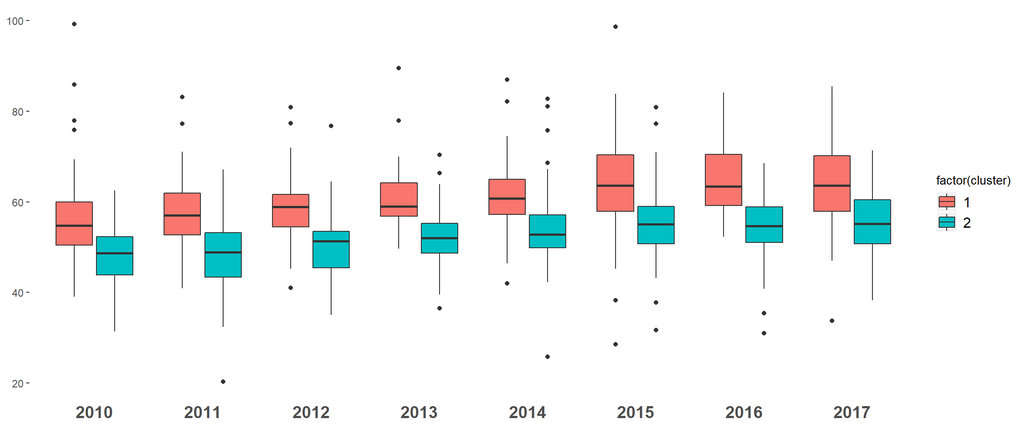

```r
#gathered_quociente <- gathered_quociente %<%
 #                     group_by(substr(data,1,4))


ggplot(gathered_quociente, aes(x= substr(Data,1,4), y = quociente, fill= factor(cluster))) +
  geom_boxplot()+
  #geom_line(aes(group= fct_reorder(UF, as.numeric(cluster)+media_estado/100, desc= TRUE))) +
  xlab("Data") +
  theme(legend.title = element_text(size = 10),
        legend.text = element_text(size = 12),
        plot.title = element_text(size=16),
        axis.title=element_text(size=14,face="bold"),
        axis.text.x = element_text(size=14,face="bold"),
        axis.title.x = element_blank(),
        axis.ticks.x = element_blank(),
        axis.title.y = element_blank(),
        panel.grid = element_blank(),
        panel.background = element_blank(),
        panel.border = element_blank()

        ) #+
```

```r
  #facet_grid(cluster~., space = "free_y")
```

# Evolução anual do indicador para cada cluster

Os dois gráficos abaixo a análise é feita para cada grupo em separadao. O objetivo aqui é identificar como os indicadores evoluíram ao longo dos anos. Recorre-se a procedimentos estatísticos para se observar se as médias anuais são estatísticamente diferentes ano a ano. cores iguais representam médias estatisticamente iguais. O gráfico em forma de violino mostra como se distribui os valores do indicador para cada ano. Quanto mais largo o gráfico maior a concentração de pontos em torno do valor representado no eixo y.

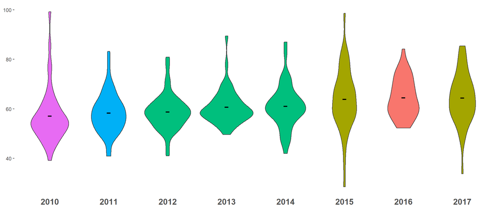

```r
library(agricolae)

####Cluster 1



dados_cluster_1 <- gathered_quociente %>%
                   filter(cluster==1) %>%
                   mutate(ano = substr(Data,1,4))

formula <- quociente ~ ano

dados_origem <- dados_cluster_1%>%
                dplyr::select(c(10,4,2))

grafico_serie_anova(formula,dados_origem)
```

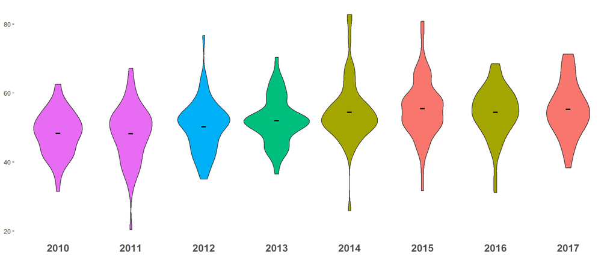

```r
####### Cluster 2
dados_cluster_2 <- gathered_quociente %>%
                   filter(cluster==2) %>%
                   mutate(ano = substr(Data,1,4))

formula <- quociente ~ ano

dados_origem <- dados_cluster_2%>%
                dplyr::select(c(10,4))

grafico_serie_anova(formula,dados_origem)
```

# Análise de evolução do componente **despesas com servidores ativos**

Os dois gráficos a seguir mostram qual a contribuição do indicador de despesas com servidores ativos. A leitura dos gráficos segue a mesma lógica dos gráficos anteriores.

```r
library(car)
library(ckanr)

source("mapa_de_calor_Despesas_pessoal_estados.R")
serie_analise <- adicionaBaseEstados(2)


gathered_quociente<- gathered_quociente %>%
  mutate(Data = paste0(substr(Data,1,7),"-01"))


df_trabalho_anova <- serie_analise %>%
  filter(Rubrica %in% c("211-REMUNERACAO DE EMPREGADOS - SALARIOS E VENCIMENTOS","212-REMUNERACAO DE EMPREGADOS - CONTRIBUICOES SOCIAIS","273-BENEFICIOS SOCIAIS - BENEFICIOS SOCIAIS DO EMPREGADOR", "Total-Receitas")) %>%
  spread(Rubrica, Valor) %>%
  mutate(Data = paste0(substr(Data,1,7),"-01"))%>%
  mutate(ano = substring(Data,1,4))%>%
  inner_join(gathered_quociente)%>%
  dplyr:: select(c(7,1,2,12,3:11))

names(df_trabalho_anova)[5:8] <- c("salarios_vencimentos", "contribuicoes_sociais", "beneficios_sociais_empregador", "receita")
```

**Cluster 1**

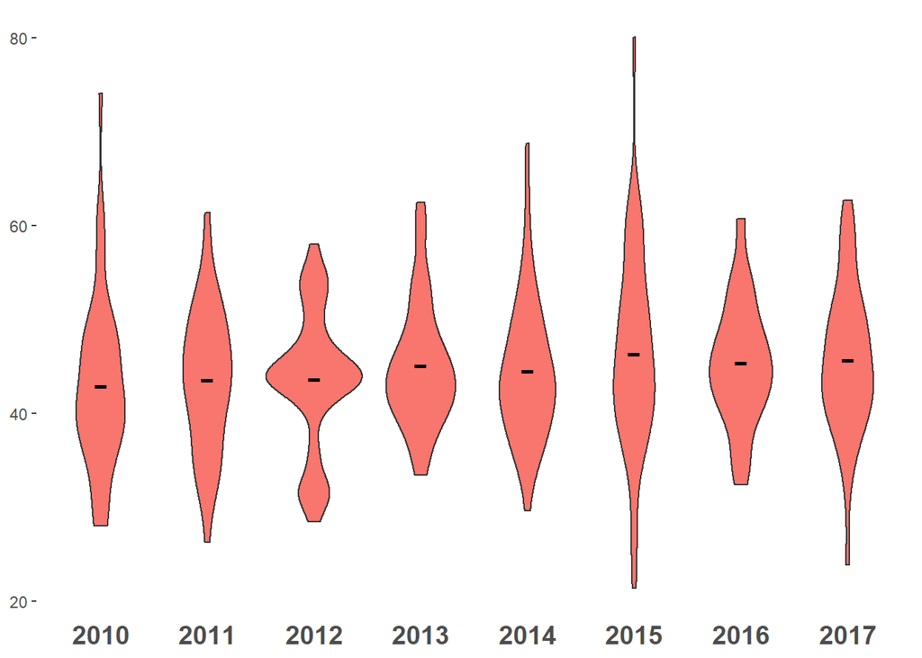

```r
dados_origem <- df_trabalho_anova %>%
                filter(cluster==1) %>%
                mutate(componente_despesa_ativo= ((salarios_vencimentos+contribuicoes_sociais)/receita)*100) %>%
                dplyr:: select(ano,componente_despesa_ativo)

formula <- componente_despesa_ativo ~ ano

grafico_serie_anova(formula,dados_origem)
```

**Cluster 2**

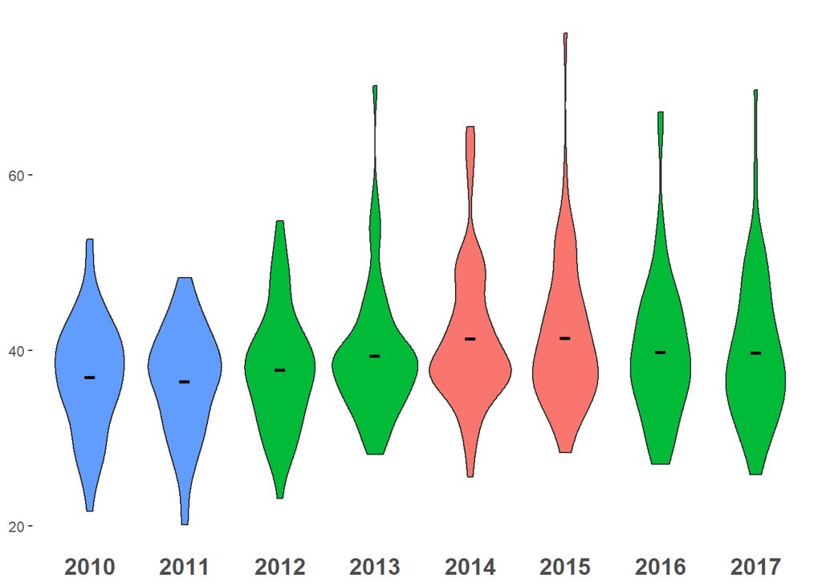

```r
dados_origem <- df_trabalho_anova %>%
                filter(cluster==2) %>%
                mutate(componente_despesa_ativo= ((salarios_vencimentos+contribuicoes_sociais)/receita)*100) %>%
                dplyr:: select(ano,componente_despesa_ativo)

formula <- componente_despesa_ativo ~ ano

grafico_serie_anova(formula,dados_origem)
```

## Análise de evolução do componente **despesas com pessoal inativo**

Já os dois próxmos gráficos tratam da contribuição do indicador de despesas com servidores inativos.

**Cluster 1**

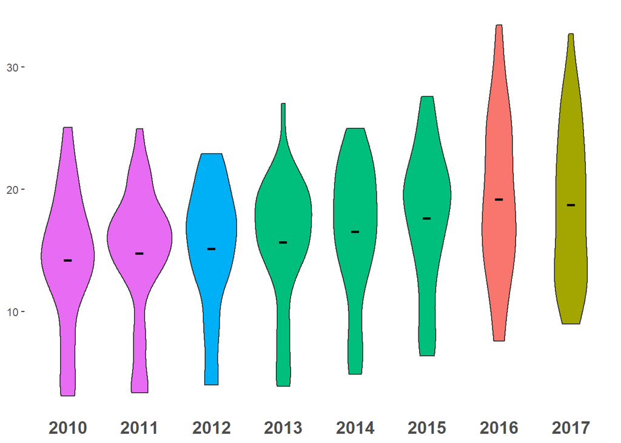

```r
dados_origem <- df_trabalho_anova %>%
                filter(cluster==1) %>%
                mutate(componente_despesa_inativo= ((beneficios_sociais_empregador)/receita)*100) %>%
                dplyr:: select(ano,componente_despesa_inativo)

formula <- componente_despesa_inativo ~ ano

grafico_serie_anova(formula,dados_origem)
```

```r
# df_trabalho_anova_cluster_1 <- df_trabalho_anova_cluster_1 %>%
#   mutate(componente_despesa_inativo= (beneficios_sociais_empregador)/receita)
#
# formula <- componente_despesa_inativo ~ ano
#
# dados_origem <- df_trabalho_anova_cluster_1 %>%
#                 dplyr:: select(ano,componente_despesa_inativo)
#
# grafico_serie_anova(formula,dados_origem)
```

**Cluster 2**

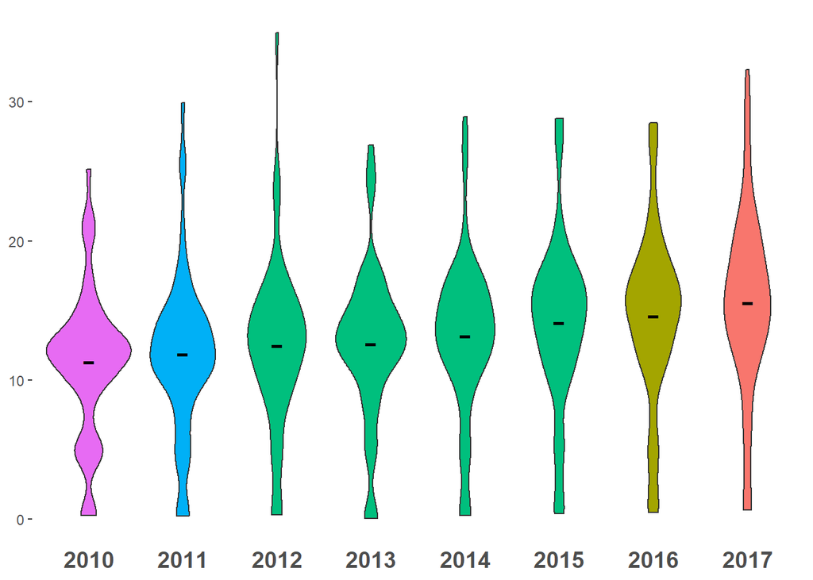

```r
dados_origem <- df_trabalho_anova %>%
                filter(cluster==2) %>%
                mutate(componente_despesa_inativo= ((beneficios_sociais_empregador)/receita)*100) %>%
                dplyr:: select(ano,componente_despesa_inativo)

formula <- componente_despesa_inativo ~ ano

grafico_serie_anova(formula,dados_origem)
```